# Uma análise dos 250 melhores filmes do IMDB

Caroline Neves

2023-04-09

```r
library(tidyverse)
library(dplyr)
library(janitor)
library(lubridate)
library(readr)
library(readr)
imdb_top_movies <- read_csv("C:/Users/Caroline/Downloads/imdb_analise - IMDB Top 250 Movies.csv")
```

```
## ──────────────────────────────────────────────────────── Delimiter: "," chr
## (15): name, genre, certificate, run_time, tagline, budget, box_office, c... dbl
## (3): rank, year, rating lgl (4): ...14, ...15, ...21, ...22
```

## Os favoritos da crítica

O IMDB é uma das maiores base de dados online de informação sobre cinema TV, música e games. Seus usuários podem avaliar os conteúdos com os quais interagiu, tendo a possibilidade de deixar cometários à respeito de sua avaliação. O conjunto de dados, disponível na plataforma Kaggle, foram extraídos do site do IMDB, no ano de 2021. No gráfico abaixo, podemos observar os gêneros que mais aparecem no top 250 do IMDB.

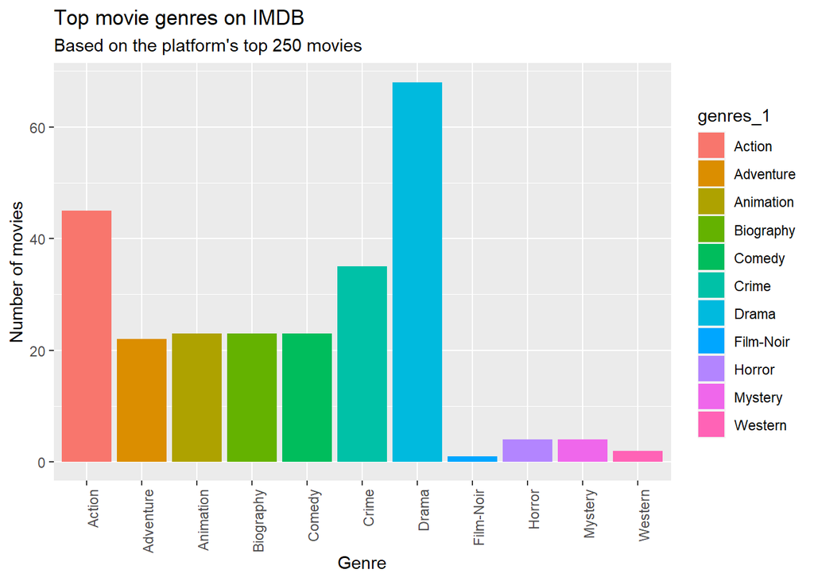

```r
genres_count <- imdb_top_movies %>%
  select(rank, name, year, genres_1) %>%
  group_by(genres_1) %>%
  summarize(n = n()) %>%
  arrange(desc(n))
View(genres_count)

ggplot(genres_count, aes(x = genres_1, y = n, fill = genres_1)) +
  geom_bar(stat = "identity") +
  labs(title = "Top movie genres on IMDB",
       subtitle = "Based on the platform's top 250 movies",
       x = "Genre",
       y = "Number of movies") +
  theme(axis.text.x = element_text(angle = 90, hjust = 1))
```

##Emoção e adrenalina! A primeira instância, podemos perceber que os filmes de ação e drama são os preferidos e mais bem avaliados, entre os usuários da plataforma. No gráfico abaixo, podemos ver a ocorrência dos filmes destes gêneros de forma mais clara. Dentre os 250 filmes, mais de 60 são filmes de drama e mais de 40 são filmes de ação!

```r
drama_action_films <- imdb_top_movies %>%
  filter(genres_1 == "Drama" | genres_1 == "Action")

#Verificar a quantidade de filmes selecionados
nrow(drama_action_films)
```

```
## [1] 113
```

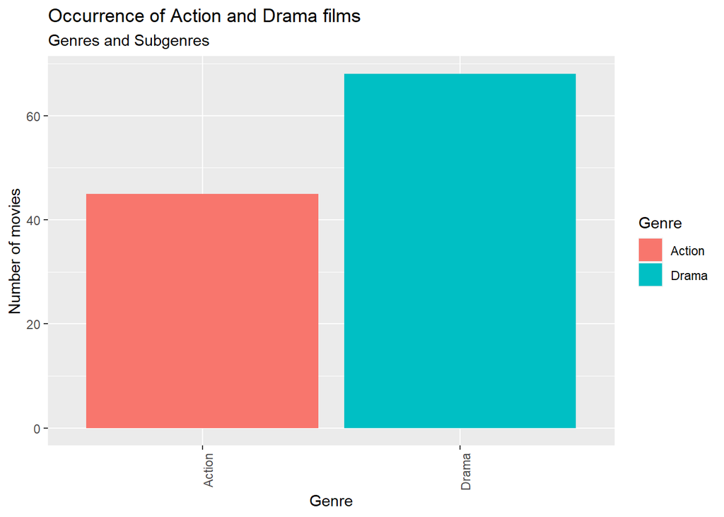

```r
#contagem de filmes por gênero
genre_count <- drama_action_films %>%
  group_by(genres_1) %>%
  summarise(count = n()) %>%
  arrange(desc(count))

#plotando gráfico de barras
ggplot(genre_count, aes(x = genres_1, y = count, fill = genres_1)) +
  geom_bar(stat = "identity") +
  labs(title = "Occurrence of Action and Drama films", subtitle= "Genres and Subgenres",
       x = "Genre",
       y = "Number of movies") +
  theme(axis.text.x = element_text(angle = 90, hjust = 1)) +
  scale_fill_discrete(name = "Genre")
```

```r
imdb_top_movies %>% dplyr::count(subgenres_1=="Action_Adventure")
```

```
## # A tibble: 2 × 2
##   `subgenres_1 == "Action_Adventure"`     n
##   <lgl>                               <int>
## 1 FALSE                                 231
## 2 TRUE                                   19
```

```r
imdb_top_movies %>% dplyr::count(subgenres_1=="Action_Biography")
```

```
## # A tibble: 2 × 2
##   `subgenres_1 == "Action_Biography"`     n
##   <lgl>                               <int>
## 1 FALSE                                 247
## 2 TRUE                                    3
```

```r
imdb_top_movies %>% dplyr::count(subgenres_1=="Action_Comedy")
```

```
## # A tibble: 2 × 2
##   `subgenres_1 == "Action_Comedy"`     n
##   <lgl>                            <int>
## 1 FALSE                              248
## 2 TRUE                                 2
```

```r
imdb_top_movies %>% dplyr::count(subgenres_1=="Action_Crime")
```

```
## # A tibble: 2 × 2
##   `subgenres_1 == "Action_Crime"`     n
##   <lgl>                           <int>
## 1 FALSE                             245
## 2 TRUE                                5
```

```r
imdb_top_movies %>% dplyr::count(subgenres_1=="Action_Drama")
```

```
## # A tibble: 2 × 2
##   `subgenres_1 == "Action_Drama"`     n
##   <lgl>                           <int>
## 1 FALSE                             238
## 2 TRUE                               12
```

```r
imdb_top_movies %>% dplyr::count(subgenres_1=="Action_Sci-fi")
```

```
## # A tibble: 1 × 2
##   `subgenres_1 == "Action_Sci-fi"`     n
##   <lgl>                            <int>
## 1 FALSE                              250
```

```r
imdb_top_movies %>% dplyr::count(subgenres_1=="Action_Thriller")
```

```
## # A tibble: 2 × 2
##   `subgenres_1 == "Action_Thriller"`     n
##   <lgl>                              <int>
## 1 FALSE                                249
## 2 TRUE                                   1
```

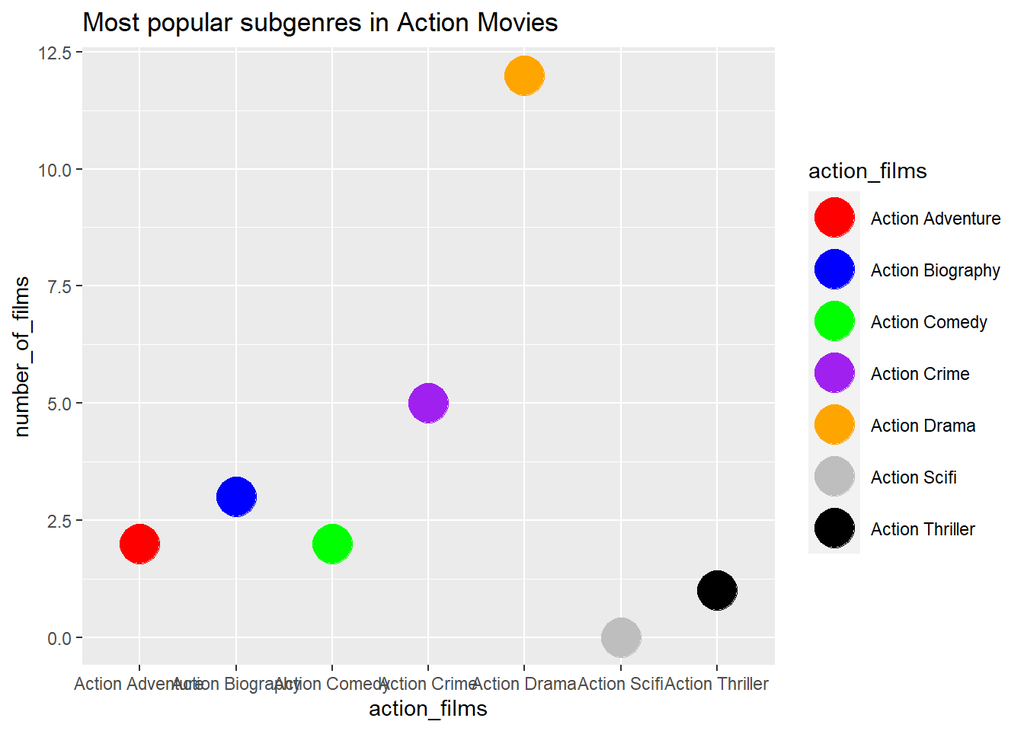

```r
#criando um dataframe com os dados obtidos para criação do gráfico
action_films <- c("Action Adventure", "Action Biography","Action Comedy","Action Crime","Action Drama","Action Scifi","Action Thriller")
number_of_films <- c(2,3,2,5,12,0,1)
action_subgenres <- data.frame(action_films <- c("Action Adventure", "Action Biography",
"Action Comedy","Action Crime","Action Drama","Action Scifi","Action Thriller"), number_of_films <- c(2,3,2,5,12,0,1))
View(action_subgenres)

colors <- c("red", "blue", "green", "purple", "orange", "gray", "black")

#plotando o gráfico
ggplot(data = action_subgenres) +
  geom_point(mapping = aes(x = action_films, y = number_of_films, color = action_films), size = 9) +
  scale_color_manual(values = colors) +
  labs(title = "Most popular subgenres in Action Movies",
       xlab = "Subgenre",
       ylab = "Number of films")
```

```r
#contando o subgeneros de drama
drama_subgenres <- imdb_top_movies %>%
  filter(grepl("Drama", genres_1)) %>%
  summarise(total_movies = n())
View(drama_subgenres)

imdb_top_movies %>% dplyr::count(subgenres_1=="Drama_Family") #4
```

```
## # A tibble: 2 × 2
##   `subgenres_1 == "Drama_Family"`     n
##   <lgl>                           <int>
## 1 FALSE                             246
## 2 TRUE                                4
```

```r
imdb_top_movies %>% dplyr::count(subgenres_1=="Drama_Fantasy") #2
```

```
## # A tibble: 2 × 2
##   `subgenres_1 == "Drama_Fantasy"`     n
##   <lgl>                            <int>
## 1 FALSE                              248
## 2 TRUE                                 2
```

```r
imdb_top_movies %>% dplyr::count(subgenres_1=="Drama_Film-Noir") #2
```

```
## # A tibble: 2 × 2
##   `subgenres_1 == "Drama_Film-Noir"`     n
##   <lgl>                              <int>
## 1 FALSE                                248
## 2 TRUE                                   2
```

```r
imdb_top_movies %>% dplyr::count(subgenres_1=="Drama_Horror") #1
```

```
## # A tibble: 2 × 2
##   `subgenres_1 == "Drama_Horror"`     n
##   <lgl>                           <int>
## 1 FALSE                             249
## 2 TRUE                                1
```

```r
imdb_top_movies %>% dplyr::count(subgenres_1=="Drama_Music") #1
```

```
## # A tibble: 2 × 2
##   `subgenres_1 == "Drama_Music"`     n
##   <lgl>                          <int>
## 1 FALSE                            249
## 2 TRUE                               1
```

```r
imdb_top_movies %>% dplyr::count(subgenres_1=="Drama_Mystery") #10
```

```
## # A tibble: 2 × 2
##   `subgenres_1 == "Drama_Mystery"`     n
##   <lgl>                            <int>
## 1 FALSE                              240
## 2 TRUE                                10
```

```r
imdb_top_movies %>% dplyr::count(subgenres_1=="Drama_Romance") #11
```

```
## # A tibble: 2 × 2
##   `subgenres_1 == "Drama_Romance"`     n
##   <lgl>                            <int>
## 1 FALSE                              239
## 2 TRUE                                11
```

```r
imdb_top_movies %>% dplyr::count(subgenres_1=="Drama_Sci-Fi") #1
```

```
## # A tibble: 2 × 2
##   `subgenres_1 == "Drama_Sci-Fi"`     n
##   <lgl>                           <int>
## 1 FALSE                             249
## 2 TRUE                                1
```

```r
imdb_top_movies %>% dplyr::count(subgenres_1=="Drama_Sport") #2
```

```
## # A tibble: 2 × 2
##   `subgenres_1 == "Drama_Sport"`     n
##   <lgl>                          <int>
## 1 FALSE                            248
## 2 TRUE                               2
```

```r
imdb_top_movies %>% dplyr::count(subgenres_1=="Drama_Thriller") #5
```

```
## # A tibble: 2 × 2
##   `subgenres_1 == "Drama_Thriller"`     n
##   <lgl>                             <int>
## 1 FALSE                               245
## 2 TRUE                                  5
```

```r
imdb_top_movies %>% dplyr::count(subgenres_1=="Drama_War") #8
```

```
## # A tibble: 2 × 2
##   `subgenres_1 == "Drama_War"`     n
##   <lgl>                        <int>
## 1 FALSE                          242
## 2 TRUE                             8
```

```r
imdb_top_movies %>% dplyr::count(subgenres_1=="Drama_Western") #2
```

```
## # A tibble: 2 × 2
##   `subgenres_1 == "Drama_Western"`     n
##   <lgl>                            <int>
## 1 FALSE                              248
## 2 TRUE                                 2
```

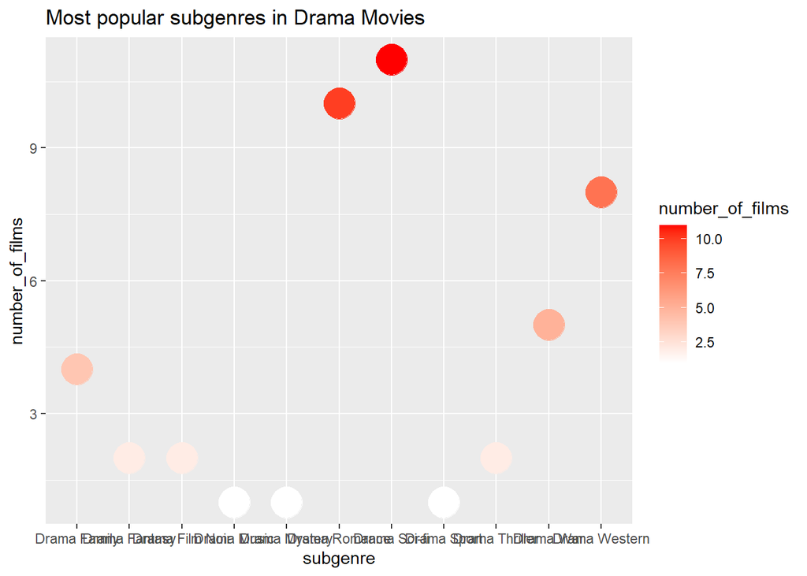

```r
#criando um dataframe com os dados obtidos para criação do gráfico
drama_subgenres <- data.frame(subgenre = c("Drama Family", "Drama Fantasy",
                                           "Drama Film Noir", "Drama Music",
                                           "Drama Mystery", "Drama Romance", "Drama Sci-fi", "Drama Sport",
                                           "Drama Thriller", "Drama War", "Drama Western"),
number_of_films = c(4, 2, 2, 1, 1, 10, 11, 1, 2, 5, 8))

#plotando o gráfico
ggplot(data = drama_subgenres) +
  geom_point(mapping = aes(x = subgenre, y = number_of_films, color = number_of_films), size = 9) +
  scale_color_gradient(low = "white", high = "red") +
  labs(title = "Most popular subgenres in Drama Movies",
       xlab = "Subgenre",
       ylab = "Number of films")
```

##Nada de clássicos! E quando se trata dos anos de lançamentos, podemos ver uma tedência à melhores classificações para os filmes lançados nos ultimos 40 anos, principalmente quando se trata de filmes de ação.

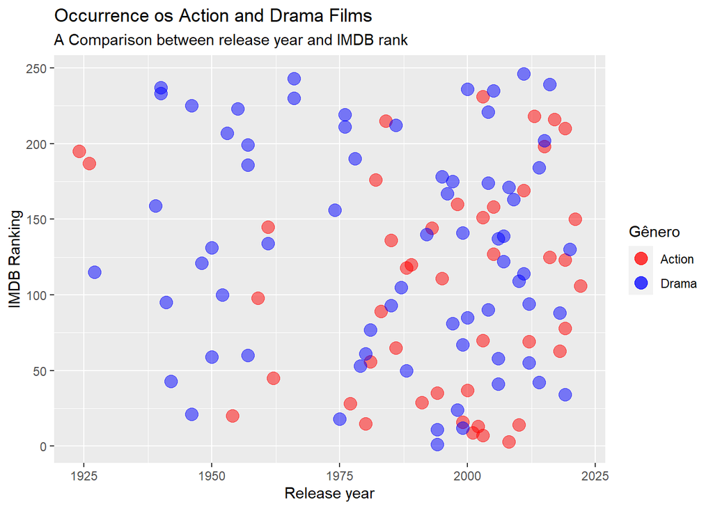

```r
action_movies <- imdb_top_movies %>% filter(genres_1 == "Action")
drama_movies <- imdb_top_movies %>% filter(genres_1 == "Drama")

#plotando o gráfico
ggplot()+
  geom_point(data = action_movies, aes(x = year, y= rank, color="Action"), alpha = 0.5, size = 4)+
  geom_point(data = drama_movies, aes(x= year, y=rank, color="Drama"), alpha= 0.5, size = 4)+
  labs(title= "Occurrence os Action and Drama Films",
  subtitle= "A Comparison between release year and IMDB rank",
  x= "Release year",
  y= "IMDB Ranking",
  color= "Gênero")+
  scale_color_manual(values= c("Action"= "red", "Drama" = "blue"))
```